# Third Week: Exploratory Data Analysis

LaLiga Analysis

niloofar tarighat 94101448

2018-02-28 00:01:42

# تمرین سری سوم: از لالیگا تا لیگ برتر

> با استفاده از داده های لیگ دسته اول اسپانیا به سوالات زیر پاسخ دهید. از هر دو ابزار ggplot2 و highcharter برای این کار تصویرسازی استفاده نمایید.

۱. تعداد قهرمانی های تیم ها در تاریخ لالیگا را استخراج کرده و نمودار ستونی آنها را رسم کنید.

برای هر تیم امتیاز را در هر فصل محاسبه میکنیم و بر اساس آن قهرمان هر فصل مشخص میشود .(با جی جی پلات و های چارت نمودار ستونی ای برای تیم های قهرمان شده رسم میکنیم

```r
library(devtools)
library(engsoccerdata)
library(dplyr)
```

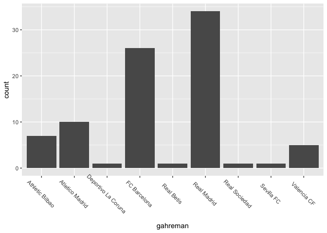

```r
library(highcharter)
spain %>%
  filter(tier == 1) -> pl

rbind(
 pl %>%
    select(Season, team = home, opp = visitor, GF = hgoal, GA = vgoal),
 pl %>%
    select(Season, team = visitor, opp = home, GF = vgoal, GA = hgoal)
)%>% mutate(GD = GF-GA) %>%
  group_by(team,Season) %>%
  summarize(GP = n(),
            goalsF = sum(GF),
            goalsA = sum(GA),
            goaldif = sum(GD),
            W = sum(GD>0),
            D = sum(GD==0),
            L = sum(GD<0)
  ) %>%
  mutate(score = W*3 + D) %>%
  arrange(Season,desc(score))->final

final %>% group_by(Season) %>% summarise(gahreman=team[which.max(score)])->gahremandata

gahremandata %>% select(gahreman) %>% distinct()->champ
count_champ=dim(champ)[1]

library(ggplot2)
p = ggplot(gahremandata, aes(x=gahreman))
p + geom_bar()+theme(axis.text.x = element_text(angle = -45,vjust = 0.65))
```

```r
gahremandata %>% group_by(gahreman) %>% summarise(count=n())->stat
stat %>%  hchart(type = "column",hcaes(x = gahreman,y=count),name = "champ")
```

[interactive chart not shown]

۲. کسل کننده ترین لیگ و تیم را بیابید. نمودار ده تیم و ده فصل کسل کننده را رسم کنید.

کسل کننده ترین تیم را تیمی تعریف کردیم که تعداد گل کمتری نسبت به تعداد بازی های انجام شده زده . برای بدست آوردن کسل کننده ترین تیم گل های هر تیم در طول فصل های مختلف را با هم جمع کردیم تیمی که کمترین گل را داشت به عتوان کسل کننده ترین تیم معرفی شد تعداد گل های زده شده در طول هر فصل هم معیاری برای تشخیص کسل کننده ترین لیگ معرفی شد نمودار ستونی امتیاز ۱۰ فصل کسل کننده و ۱۰ تیم کسل کننده ی برتر هم رسم شد.

```r
library(devtools)
library(engsoccerdata)
library(dplyr)
library(highcharter)
spain %>%
  filter(tier == 1) -> pl

rbind(
  pl %>%
    select(Season, team = home, opp = visitor, GF = hgoal, GA = vgoal),
  pl %>%
    select(Season, team = visitor, opp = home, GF = vgoal, GA = hgoal)
)%>% mutate(GD = GF-GA) %>%
  group_by(team,Season) %>%
  summarize(GP = n(),
            goalsF = sum(GF),
            goalsA = sum(GA),
            goaldif = sum(GD),
            W = sum(GD>0),
            D = sum(GD==0),
            L = sum(GD<0)
  ) %>%
  mutate(score = W*3 + D) %>%
  arrange(Season,desc(score))->final

#kesel konande tarin league
final %>% group_by(Season) %>% summarise(totgoal=sum(goalsF))->stat
cat("kesel konande tarin league :",stat$Season[which.min(stat$totgoal)])
```

```
## kesel konande tarin league : 1931
```

```r
#kesel konande tarin team
final %>% group_by(team) %>% summarise(totgoal=sum(goalsF),count=n()) %>% mutate(totgoal_norm=totgoal/count)->stat_team
cat("kesel konande tarin team :",stat_team$team[which.min(stat_team$totgoal_norm)])
```

```
## kesel konande tarin team : Pontevedra CF
```

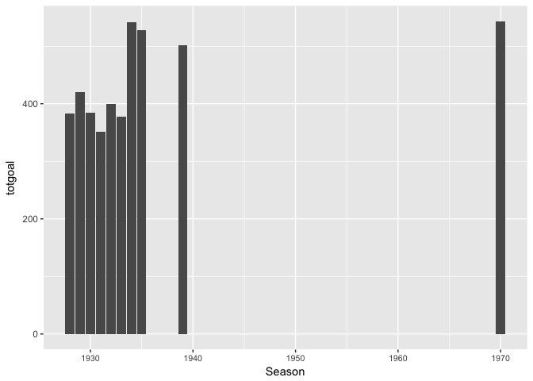

```r
stat %>% arrange(desc(-totgoal))->statsorted
top_bor_league=statsorted[1:10,]

p = ggplot(data = top_bor_league,aes(x =Season,y = totgoal))
p + geom_bar(stat ="identity")+theme(axis.text.x = element_text(size = 8))
```

```r
top_bor_league %>% hchart(type= "column",hcaes(x =Season,y = totgoal))
```

[interactive chart not shown]

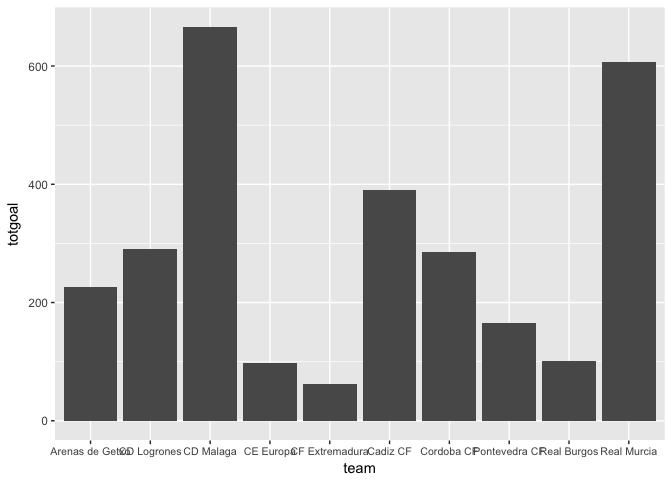

```r
stat_team %>% arrange(desc(-totgoal_norm))->statsorted_team
top_bor_team=statsorted_team[1:10,]
p = ggplot(top_bor_team, aes(x=team,y=totgoal))+theme(axis.text.x = element_text(size = 8))
p + geom_bar(stat ="identity")
```

```r
top_bor_team %>% hchart(type= "column",hcaes(x=team,y=totgoal))
```

[interactive chart not shown]

۳. در چند درصد موارد قهرمان نیم فصل در پایان فصل قهرمان شده است؟

در این سوال به طریق نوشتن تابعی بازی های نیم فصل جدا شده و قهرمان آن مطابق روند معمول پیدا شده .همچنین قهرمان کل فصل را هم پیدا کردیم و در صورت تطابق متغیری را اضافه کردیم نسبت تطابق ها به نسبت کل تعداد فصل ها عدد خروجی است

```r
library(devtools)
library(engsoccerdata)
library(dplyr)
per=0

spain %>%
  filter(tier == 1) -> pl


pl %>% group_by(Season) %>% summarise(count=n())->counts
index=cumsum(counts)

half<-function(Begin,End){

  halfdf<-pl[(Begin:((Begin+End)/2)),]
  return(halfdf)
}

b=1
for (i in c(1:86)) {


  End=index[i,2]
  e=as.integer(End[1,1])
  df=half(b,e)

  rbind(
    df %>%
      select(Season, team = home, opp = visitor, GF = hgoal, GA = vgoal),
    df %>%
      select(Season, team = visitor, opp = home, GF = vgoal, GA = hgoal)
  ) %>% mutate(GD = GF-GA) %>%
    group_by(team) %>%
    summarize(GP = n(),
              goalsF = sum(GF),
              goalsA = sum(GA),
              goaldif = sum(GD),
              W = sum(GD>0),
              D = sum(GD==0),
              L = sum(GD<0)
    ) %>%
    mutate(score = W*3 + D) %>%
    arrange(desc(score)) ->final
    champ_season=final$team[which.max(final$score)]

    tot=pl[b:e,]
    rbind(
      tot %>%
        select(Season, team = home, opp = visitor, GF = hgoal, GA = vgoal),
      tot %>%
        select(Season, team = visitor, opp = home, GF = vgoal, GA = hgoal)
    ) %>% mutate(GD = GF-GA) %>%
      group_by(team) %>%
      summarize(GP = n(),
                goalsF = sum(GF),
                goalsA = sum(GA),
                goaldif = sum(GD),
                W = sum(GD>0),
                D = sum(GD==0),
                L = sum(GD<0)
      ) %>%
      mutate(score = W*3 + D) %>%
      arrange(desc(score)) ->tot_final
    champ_totseason=tot_final$team[which.max(tot_final$score)]

    if(champ_season==champ_totseason){
      per=per+1
    }



  Begin=index[i,2]+1
  b=as.integer(Begin[1,1])
}


cat("in what percent of seasons the half season champion became the season champion:",100*per/86)
```

```
## in what percent of seasons the half season champion became the season champion: 53.48837
```

۴. در بین سال های ۲۰۰۱ تا ۲۰۱۰ گربه سیاه تیم های بزرگ چه تیم هایی بوده است؟

```r
library(devtools)
library(dplyr)
library(engsoccerdata)

#filter kardan data ba season va tier 1
spain %>% filter(tier==1) -> df
df %>% filter(Season>2000)->df
df %>% filter(Season<2011)->df

#peida kardan team bozorg va zaeif har season....big,loosers

rbind(
  df %>%
    select(Season, team = home, opp = visitor, GF = hgoal, GA = vgoal),
  df %>%
    select(Season, team = visitor, opp = home, GF = vgoal, GA = hgoal)
) %>% mutate(GD = GF-GA) %>%
  group_by(team,Season) %>%
  summarize(GP = n(),
            goalsF = sum(GF),
            goalsA = sum(GA),
            goaldif = sum(GD),
            W = sum(GD>0),
            D = sum(GD==0),
            L = sum(GD<0)
  ) %>%
  mutate(score = W*3 + D) %>%
  arrange(Season,desc(score)) %>% group_by(Season)->data

data %>% mutate(rank = rank(-score) %>% as.integer())->df_sorted1
df_sorted1 %>% group_by(Season) %>% filter(rank<4)->big


data %>% mutate(rank = rank(score) %>% as.integer())->df_sorted2
df_sorted2 %>% group_by(Season) %>% filter(rank <4 )->bad

blackcat_tot <- data.frame(bc=character(),
                              season=integer(),
                              stringsAsFactors=FALSE)


for (i in c(1:10)) {
 big_season=big %>% filter(Season==2000+i) %>% select(Season,team)
 bad_season=bad %>% filter(Season==2000+i) %>% select(Season,team)

 game=df %>% filter(Season==2000+i) %>% filter(home==as.character(big_season[1,2]) |home==as.character(big_season[2,2])|home==as.character(big_season[3,2]))
 game2=game %>% filter(visitor==as.character(bad_season[1,2]) |home==as.character(bad_season[2,2])|home==as.character(bad_season[3,2]))
 game3=game2 %>% filter(vgoal>hgoal)
 game3 %>% select(bc=visitor,Season)->blackcat1

 game4=df %>% filter(Season==2000+i) %>% filter(visitor==as.character(big_season[1,2]) |home==as.character(big_season[2,2])|home==as.character(big_season[3,2]))
 game5=game4 %>% filter(home==as.character(bad_season[1,2]) |home==as.character(bad_season[2,2])|home==as.character(bad_season[3,2]))
 game6=game5 %>% filter(hgoal>=vgoal)
 game6 %>% select(bc=home,Season)->blackcat2

 blackcat=rbind(blackcat1,blackcat2)
 blackcat_tot=rbind(blackcat_tot,blackcat)
}

print(blackcat_tot)
```

```
##                   bc Season
## 1  Recreativo Huelva   2002
## 2        Real Murcia   2003
## 3    Real Valladolid   2003
## 4        CD Numancia   2004
## 5         Levante UD   2004
## 6          CD Alaves   2005
## 7          Malaga CF   2005
## 8         Celta Vigo   2006
## 9        Real Murcia   2007
## 10     Real Zaragoza   2007
## 11         Getafe CF   2008
## 12       CD Numancia   2008
## 13        Real Betis   2008
```

۵. در تاریخ لالیگا کدام تیم رکورددار زودترین قهرمانی است؟ همچنین کدام تیم مقتدرانه ترین قهرمانی را داشته است؟

تیمی که با تعداد بازی های باقیمانده بیشتری قهرمان میشود رکورددار است . مقتدرترین قهرمان کسی است که با بیشترین اختلاف از نفر دوم قهرمان شده باشد .

چند تیم قهرمان زودهنگام چاپ شد و در بین آنها ریال مادرید رکورددار قهرمانی ایست.

```r
library(devtools)
library(engsoccerdata)
library(dplyr)

spain %>%
  filter(tier == 1) -> pl
pl %>% select(Date,Season,home,visitor,hgoal,vgoal)->pl
seasons=pl %>% select(Season) %>% distinct()

for (i in c(1:86)) {
  data=pl %>% filter(Season==seasons[i,1])
  d=dim(data)[1] %>% as.integer()

  teams=data %>% select(team=home) %>% distinct()
  zero=matrix(0,nrow =dim(teams)[1] %>% as.integer() ,ncol = 1)
  final=data.frame(name=teams,score=zero)


  for (j in c(1:d)) {
    local=data[j,]
    if(local$hgoal==local$vgoal){
      final$score[which(local$home==final$team)]=local$hgoal+final$score[which(local$home==final$team)]
      final$score[which(local$visitor==final$team)]=local$vgoal+final$score[which(local$visitor==final$team)]
    }

    if(local$hgoal>local$vgoal){
      final$score[which(local$home==final$team)]=3*local$hgoal+final$score[which(local$home==final$team)]

    }

    if(local$hgoal<local$vgoal){

      final$score[which(local$visitor==final$team)]=3*local$vgoal+final$score[which(local$visitor==final$team)]
    }



    final %>% mutate(rank=rank(-score) %>% as.integer()) %>% arrange(desc(-rank))->final

    gap=final[1,2]-final[2,2]
    time=d-j

    if(gap>3*time & time>38){
      print(final[1,1])
      print(time)
      print(local$Date)

    }



    }

  }
```

```
## [1] "Real Madrid"
## [1] 42
## [1] "1961-03-12"
## [1] "Real Madrid"
## [1] 41
## [1] "1961-03-12"
## [1] "Real Madrid"
## [1] 40
## [1] "1961-03-12"
## [1] "Real Madrid"
## [1] 39
## [1] "1961-03-19"
```

```r
#moghtadertarin:!
library(devtools)
library(engsoccerdata)
library(dplyr)

spain %>%
  filter(tier == 1) -> pl

pl %>% select(home) %>% distinct() ->teams

pl %>% arrange(-desc(Date))->data
data %>% group_by(Season,Date) %>% mutate(equal=ifelse(hgoal==vgoal,1,0),homewin=ifelse(hgoal>vgoal,1,0),visitorwin=ifelse(hgoal<vgoal,1,0))->stat
stat %>% group_by(Season,Date) %>% mutate(homescore=equal+homewin*3,visitorscore=3*visitorwin+equal)->stat2
stat2 %>% group_by(Season) %>% mutate(count=n(),id=1,play=(count-cumsum(id)))->stat3

stat3 %>% select(Season,Date,team=home,score=homescore,play)->homedata
stat3 %>% select(Season,Date,team=visitor,score=visitorscore,play)->visitordata
scoredata=rbind(homedata,visitordata) %>% arrange(Season,team,Date)
scoredata %>% group_by(Season,team) %>% mutate(totsc=cumsum(score))->final



#moghtaderane tarin ghahremani
final %>% group_by(Season,team) %>% summarise(finalscore=sum(score))->moghtader
moghtader %>% group_by(Season) %>% mutate(rank=rank(-finalscore) %>% as.integer())->moghtader2
moghtader2 %>% group_by(Season) %>% summarise(diff=mean(finalscore[which(rank==1)]-finalscore[which(rank==2)],na.rm = T))->moghtader3
moghtaderchamp=moghtader3$Season[which.max((moghtader3$diff))]
moghtader_champion=moghtader2 %>% select(team,Season,rank) %>%  filter(Season==1962 & rank==1)
moghtader_champion
```

```
## # A tibble: 1 x 3
## # Groups:   Season [1]
##   team        Season  rank
##   <chr>        <dbl> <int>
## 1 Real Madrid   1962     1
```

۶. طولانی ترین نوار پیروزی مساوی و شکست مال چه تیم هایی است؟

تیمی که بیشترین برد -باخت-مساوی پشت هم در یک فصل را داشته طولانی ترین نوار را دارد

```r
library(devtools)
library(engsoccerdata)
library(dplyr)

spain %>%
  filter(tier == 1) -> pl


pl %>% arrange(-desc(Date))->plsort
plsort %>% group_by(Season,Date) %>%
  mutate(equal=ifelse(hgoal==vgoal,1,0),homewin=ifelse(hgoal>vgoal,1,0),homeloose=ifelse(vgoal>hgoal,1,0),visitorwin=ifelse(hgoal<vgoal,1,0),visitorloose=ifelse(vgoal<hgoal,1,0))->stat
stat %>% select(Season,Date,team=home,win=homewin,loose=homeloose,Equal=equal)->temp1
stat %>% select(Season,Date,team=visitor,win=visitorwin,loose=visitorloose,Equal=equal)->temp2
data=rbind(temp1,temp2)
data %>% arrange(Season,team)->teamdata
teamdata %>% group_by(Season,team) %>% summarise(totalwin=sum(win))->tot_win
tot_win_max=max(tot_win$totalwin)
teamdata %>% group_by(Season,team) %>% summarise(totalloose=sum(loose))->tot_loose
tot_loose_max=max(tot_loose$totalloose)
teamdata %>% group_by(Season,team) %>% summarise(totalequal=sum(Equal))->tot_equal
tot_equal_max=max(tot_equal$totalequal)

teamdata$tavali_w=0
for (i in c(1:tot_win_max)) {
  teamdata$tavali_w=ifelse(teamdata$win==lag(teamdata$win) & teamdata$win==1 &teamdata$team==lag(teamdata$team),lag(teamdata$tavali_w)+1,0)
}
teamdata %>% group_by(team) %>% summarise(Season=Season[which.max(tavali_w)],tavali_win=max(tavali_w)+1)->final
cat("longest win:",final$team[which.max(final$tavali_win)] )
```

```
## longest win: FC Barcelona
```

```r
teamdata$tavali_l=0
for (i in c(1:tot_loose_max)) {

  teamdata$tavali_l=ifelse(teamdata$loose==lag(teamdata$loose) & teamdata$loose==1 & teamdata$team==lag(teamdata$team),lag(teamdata$tavali_l)+1,0)
}
teamdata %>% group_by(team) %>% summarise(Season=Season[which.max(tavali_l)],tavali_loose=max(tavali_l)+1)->final2
cat("longest loose:",final2$team[which.max(final2$tavali_loose)] )
```

```
## longest loose: AD Almeria
```

```r
teamdata$tavali_e=0
for (i in c(1:tot_equal_max)) {
  teamdata$tavali_e=ifelse(teamdata$Equal==lag(teamdata$Equal) & teamdata$Equal==1 &teamdata$team==lag(teamdata$team),lag(teamdata$tavali_e)+1,0)
}
teamdata %>% group_by(team) %>% summarise(Season=Season[which.max(tavali_e)],tavali_equal=max(tavali_e)+1)->final3
cat("longest equal:",final3$team[which.max(final3$tavali_equal)] )
```

```
## longest equal: Hercules CF
```

۷. زودترین سقوط مال کدام تیم بوده است؟